# R Assignment 3

Chen Ming

May 20th

# Part 1

#### **1.1. Find descriptive statistics of the data and summarize them into a table**

The table is constructed as follows.

```
##    Graduation.Rate Number.of.Classes.Under.20 Student.Faculty.Ratio
## 1               85                         39                    13
## 2               79                         68                     8
## 3               93                         60                     8
## 4               85                         65                     3
## 5               75                         67                    10
## 6               72                         52                     8
## 7               89                         45                    12
## 8               90                         69                     7
## 9               91                         72                    13
## 10              94                         61                    10
## 11              92                         68                     8
## 12              84                         65                     7
## 13              91                         54                    10
## 14              97                         73                     8
```

[output cut: 83 more lines]

#### **1.2. Use graphical analysis to investigate the relationship between Alumni Giving Rate and each of the other variables**

Scatter plot is demonstrated as follows. In the first and the third graphs, we can find that points cluster closely around fitted lines. While in the second graph, points seem to drift away from fitted line. From the graphical analysis, we can reasonably assume that alumni giving rate is more closely related to both graduation rate and faculty rate than number of classes under 20.

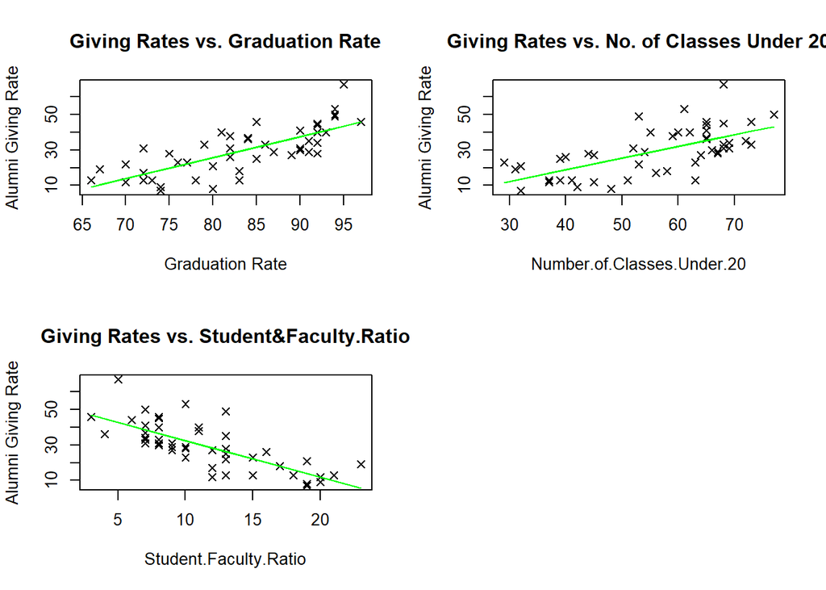

#### **1.3.Develop a multiple linear regression model that could be used to predict the Alumni Giving Rate using the data provided**

We can use function **stepAIC** to construct the best multi-linear regression model from a set of candidate variables.The experiment result indicates that, AIC value becomes smaller when the variable “Number of classes under 20” is deleted from the regression model. Since smaller AIC value means better fitting effect, we should construct a regression model with “Graduation Rates” and “Student & Faculty Ratios” as independent variables.

```
## Start:  AIC=198.65
## Alumni.Giving.Rate ~ Graduation.Rate + Number.of.Classes.Under.20 +
##     Student.Faculty.Ratio
##
##                              Df Sum of Sq    RSS    AIC
## - Number.of.Classes.Under.20  1      2.52 2550.5 196.70
## <none>                                    2547.9 198.65
## - Student.Faculty.Ratio       1    550.17 3098.1 206.03
## - Graduation.Rate             1   1176.92 3724.9 214.88
##
## Step:  AIC=196.7
## Alumni.Giving.Rate ~ Graduation.Rate + Student.Faculty.Ratio
##
##                         Df Sum of Sq    RSS    AIC
## <none>                               2550.5 196.70
## - Student.Faculty.Ratio  1    1088.5 3639.0 211.76
## - Graduation.Rate        1    1260.9 3811.4 213.98
```

```
##
## Call:
## lm(formula = Alumni.Giving.Rate ~ Graduation.Rate + Student.Faculty.Ratio,
##     data = newdataframe)
##
## Coefficients:
##           (Intercept)        Graduation.Rate  Student.Faculty.Ratio
##              -19.1063                 0.7557                -1.2460
```

```
##
## Call:
## lm(formula = Alumni.Giving.Rate ~ Graduation.Rate + Student.Faculty.Ratio,
##     data = newdataframe)
##
## Coefficients:
##           (Intercept)        Graduation.Rate  Student.Faculty.Ratio
##              -19.1063                 0.7557                -1.2460
```

```
##
## Call:
## lm(formula = Alumni.Giving.Rate ~ Graduation.Rate + Student.Faculty.Ratio,
##     data = newdataframe)
##
## Residuals:
##      Min       1Q   Median       3Q      Max
## -11.9304  -6.1594  -0.5521   3.5910  20.5412
##
## Coefficients:
##                       Estimate Std. Error t value Pr(>|t|)
## (Intercept)           -19.1063    15.5501  -1.229    0.226
## Graduation.Rate         0.7557     0.1602   4.717 2.35e-05 ***
## Student.Faculty.Ratio  -1.2460     0.2843  -4.382 6.95e-05 ***
## ---
## Signif. codes:  0 '***' 0.001 '**' 0.01 '*' 0.05 '.' 0.1 ' ' 1
##
## Residual standard error: 7.528 on 45 degrees of freedom
## Multiple R-squared:  0.6996, Adjusted R-squared:  0.6863
## F-statistic: 52.41 on 2 and 45 DF,  p-value: 1.765e-12
```

#### **1.4.Check the model assumptions**

In Q-Q graph, points closely cluster around the line, which proves that the assumption of **normality** is satisfied; there is no reason to assume that graduation ratio and faculty to student ratio is related. Therefore, the assumption of **independence** is satisfied;from graph one, we can observe that residuals is no systematic relationship between residuals and the predicted values. The model well captures systematic variance in the data, thereby proves that the assumption of **Linearity** is satisfied; the Scale-Location graph shows that the points form a random band around the horizontal line. Hence the assumption of **Homoscedasticity** is satisfied.

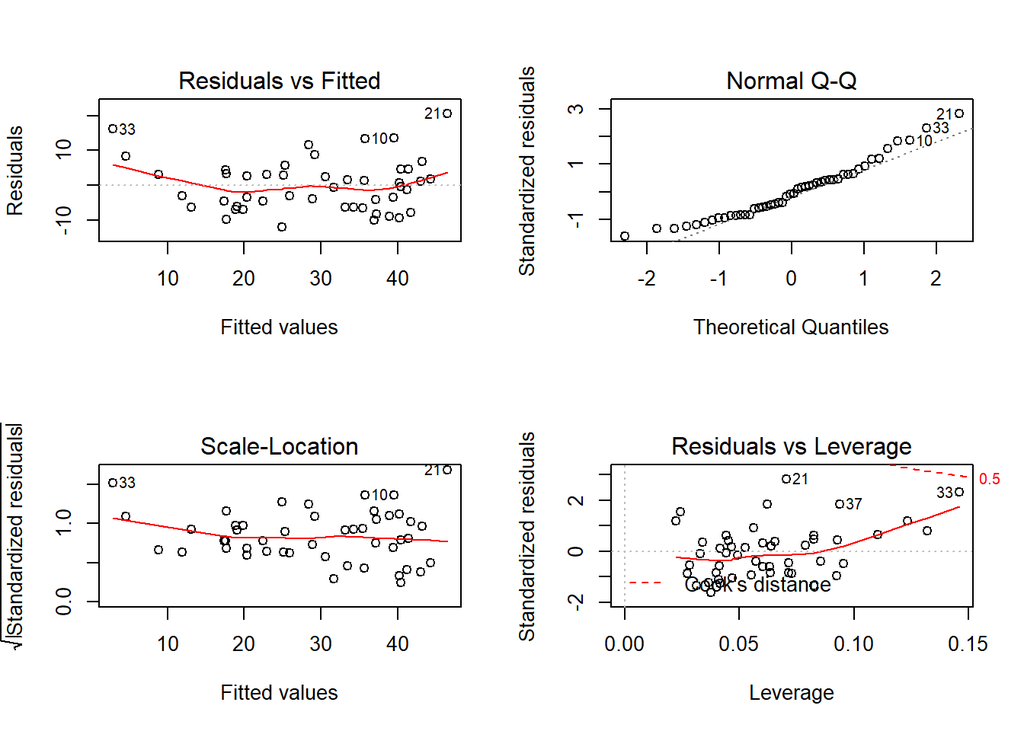

# Part 2

#### **2.1. Calculate the mean of Fertility and partition the provinces into two groups**

The mean of fertility in stated provinces is 70.14255. Group1 and group2 is illustrated as follows.

```
## [1] 70.14255
```

```
##              Fertility Agriculture Examination Education Catholic
## Courtelary        80.2        17.0          15        12     9.96
## Delemont          83.1        45.1           6         9    84.84
## Franches-Mnt      92.5        39.7           5         5    93.40
## Moutier           85.8        36.5          12         7    33.77
## Neuveville        76.9        43.5          17        15     5.16
## Porrentruy        76.1        35.3           9         7    90.57
## Broye             83.8        70.2          16         7    92.85
## Glane             92.4        67.8          14         8    97.16
## Gruyere           82.4        53.3          12         7    97.67
## Sarine            82.9        45.2          16        13    91.38
## Veveyse           87.1        64.5          14         6    98.61
## Grandson          71.7        34.0          17         8     3.30
## Oron              72.5        71.2          12         1     2.40
## Payerne           74.2        58.1          14         8     5.23
## Paysd'enhaut      72.0        63.5           6         3     2.56
## Conthey           75.5        85.9           3         2    99.71
## Herens            77.3        89.7           5         2   100.00
## Martigwy          70.5        78.2          12         6    98.96
## Monthey           79.4        64.9           7         3    98.22
## Sierre            92.2        84.6           3         3    99.46
## Sion              79.3        63.1          13        13    96.83
## Boudry            70.4        38.4          26        12     5.62
## Le Locle          72.7        16.7          22        13    11.22
## Val de Ruz        77.6        37.6          15         7     4.97
##              Infant.Mortality ynprovinces
## Courtelary               22.2           1
## Delemont                 22.2           1
## Franches-Mnt             20.2           1
## Moutier                  20.3           1
## Neuveville               20.6           1
## Porrentruy               26.6           1
## Broye                    23.6           1
## Glane                    24.9           1
## Gruyere                  21.0           1
## Sarine                   24.4           1
## Veveyse                  24.5           1
## Grandson                 20.0           1
## Oron                     21.0           1
## Payerne                  23.8           1
## Paysd'enhaut             18.0           1
## Conthey                  15.1           1
## Herens                   18.3           1
## Martigwy                 19.4           1
## Monthey                  20.2           1
## Sierre                   16.3           1
## Sion                     18.1           1
## Boudry                   20.3           1
## Le Locle                 18.9           1
## Val de Ruz               20.0           1
```

```
##              Fertility Agriculture Examination Education Catholic
## Aigle             64.1        62.0          21        12     8.52
## Aubonne           66.9        67.5          14         7     2.27
## Avenches          68.9        60.7          19        12     4.43
## Cossonay          61.7        69.3          22         5     2.82
## Echallens         68.3        72.6          18         2    24.20
## Lausanne          55.7        19.4          26        28    12.11
## La Vallee         54.3        15.2          31        20     2.15
## Lavaux            65.1        73.0          19         9     2.84
## Morges            65.5        59.8          22        10     5.23
## Moudon            65.0        55.1          14         3     4.52
## Nyone             56.6        50.9          22        12    15.14
## Orbe              57.4        54.1          20         6     4.20
## Rolle             60.5        60.8          16        10     7.72
## Vevey             58.3        26.8          25        19    18.46
## Yverdon           65.4        49.5          15         8     6.10
## Entremont         69.3        84.9           7         6    99.68
## St Maurice        65.0        75.9           9         9    99.06
## La Chauxdfnd      65.7         7.7          29        11    13.79
## Neuchatel         64.4        17.6          35        32    16.92
## ValdeTravers      67.6        18.7          25         7     8.65
## V. De Geneve      35.0         1.2          37        53    42.34
## Rive Droite       44.7        46.6          16        29    50.43
## Rive Gauche       42.8        27.7          22        29    58.33
##              Infant.Mortality ynprovinces
## Aigle                    16.5           0
## Aubonne                  19.1           0
## Avenches                 22.7           0
## Cossonay                 18.7           0
## Echallens                21.2           0
## Lausanne                 20.2           0
## La Vallee                10.8           0
## Lavaux                   20.0           0
## Morges                   18.0           0
## Moudon                   22.4           0
## Nyone                    16.7           0
## Orbe                     15.3           0
## Rolle                    16.3           0
## Vevey                    20.9           0
## Yverdon                  22.5           0
## Entremont                19.8           0
## St Maurice               17.8           0
## La Chauxdfnd             20.5           0
## Neuchatel                23.0           0
## ValdeTravers             19.5           0
## V. De Geneve             18.0           0
## Rive Droite              18.2           0
## Rive Gauche              19.3           0
```

```
##       [,1]
##  [1,]    1
##  [2,]    1
##  [3,]    1
##  [4,]    1
##  [5,]    1
##  [6,]    1
##  [7,]    1
##  [8,]    1
##  [9,]    1
## [10,]    1
## [11,]    1
## [12,]    0
## [13,]    0
## [14,]    0
```

[output cut: 33 more lines]

#### **2.2. Use logistic regression to show the relationship between y and the other variables and then interpret the regression results**

The experiment result indicates that fertility in selected provinces is significantly related to **Agriculture** and **Examination** under significance level of 0.05. It implies that fetility is closely related to agriculture situation and examination circumstance in the provinces.

```
##
## Call:
## glm(formula = y ~ Agriculture + Examination + Education + Catholic +
##     Infant.Mortality, family = binomial(), data = swiss)
##
## Deviance Residuals:
##      Min        1Q    Median        3Q       Max
## -1.85403  -0.45960   0.03648   0.55548   2.32911
##
## Coefficients:
##                  Estimate Std. Error z value Pr(>|z|)
## (Intercept)       4.82826    5.25607   0.919   0.3583
## Agriculture      -0.09615    0.04011  -2.397   0.0165 *
## Examination      -0.32116    0.13844  -2.320   0.0203 *
## Education        -0.12078    0.08610  -1.403   0.1607
## Catholic          0.02078    0.01376   1.509   0.1312
## Infant.Mortality  0.29078    0.21051   1.381   0.1672
## ---
## Signif. codes:  0 '***' 0.001 '**' 0.01 '*' 0.05 '.' 0.1 ' ' 1
##
## (Dispersion parameter for binomial family taken to be 1)
##
##     Null deviance: 65.135  on 46  degrees of freedom
## Residual deviance: 32.887  on 41  degrees of freedom
## AIC: 44.887
##
## Number of Fisher Scoring iterations: 6
```

#### **2.3. Choose a model selection criterion, for instances, AIC, BIC, adjusted R square or Cp, and use it to select a reasonable model**

We can construct the best multi-linear regression model from a set of candidate variables. Under AIC criterion, regression model with smaller AIC value is considered better. The experiment result indicates that AIC value gets smaller when the variables “Catholic” and “Education” are deleted from the regression model. Hence we should construct a regression model with **“Infant.Mortality”**, **“Agriculture”** and **“Examination”** as independent variables.

```
## Start:  AIC=-84.75
## y ~ Agriculture + Examination + Education + Catholic + Infant.Mortality
##
##                    Df Sum of Sq    RSS     AIC
## - Education         1   0.25537 6.2545 -84.792
## - Infant.Mortality  1   0.25579 6.2549 -84.789
## <none>                          5.9991 -84.751
## - Catholic          1   0.40468 6.4038 -83.683
## - Examination       1   0.93170 6.9308 -79.966
## - Agriculture       1   1.06427 7.0634 -79.075
##
## Step:  AIC=-84.79
## y ~ Agriculture + Examination + Catholic + Infant.Mortality
##
##                    Df Sum of Sq    RSS     AIC
## - Catholic          1   0.20534 6.4598 -85.274
## <none>                          6.2545 -84.792
## - Infant.Mortality  1   0.36465 6.6191 -84.129
## - Agriculture       1   0.82599 7.0805 -80.962
## - Examination       1   2.43417 8.6887 -71.342
##
## Step:  AIC=-85.27
## y ~ Agriculture + Examination + Infant.Mortality
##
##                    Df Sum of Sq     RSS     AIC
## <none>                           6.4598 -85.274
## - Infant.Mortality  1    0.4546  6.9144 -84.077
## - Agriculture       1    0.7943  7.2542 -81.823
## - Examination       1    3.7161 10.1760 -65.916
```

```
##
## Call:
## lm(formula = y ~ Agriculture + Examination + Infant.Mortality,
##     data = swiss)
##
## Coefficients:
##      (Intercept)       Agriculture       Examination  Infant.Mortality
##          1.05056          -0.00811          -0.05017           0.03501
```

```
##
## Call:
## lm(formula = y ~ Agriculture + Examination + Infant.Mortality,
##     data = swiss)
##
## Coefficients:
##      (Intercept)       Agriculture       Examination  Infant.Mortality
##          1.05056          -0.00811          -0.05017           0.03501
```